# Final Project

Introduction The NFL is a multibillion dollar industry. In today’s game there has been a premium placed upon the passing game and while there has been plenty of research done on the growth of QBs the growth of WR’s has not been as analyzed. With the premium placed on passing the amount pass catchers recieve has been constantly growing as well. As such we will determine whether or not one can predict who is under and over performing. By this I mean we will try to discover based on how many receptions a player has made in a season how many touch downs a player can be expected to make. This will also help NFL teams determine how effective a particular player is and how effective they can expect them to be.

```r
library(rvest)
library(magrittr)
library(tidyverse)
x <- {1:10}
y <- {2007:2016}

for(year in y){

  for (var in x) {
  url <-paste(paste(paste(paste("http://www.nfl.com/stats/categorystats?tabSeq=0&season=",year,sep=""),"&seasonType=REG&Submit=Go&experience=&archive=true&statisticCategory=RECEIVING&d-447263-p=",sep=""),var,sep=""),"&conference=null&qualified=false",sep="")
      All_player_page <- read_html(url)%>% html_nodes("table")%>%.[1]

     if(var==1 && year ==2007){

        all_table <- html_table(All_player_page, fill=TRUE) %>% as.data.frame()
        all_table$year <- year


     }else{
        tmp_tbl <-html_table(All_player_page, fill=TRUE) %>% as.data.frame()
        tmp_tbl$year <- year
         all_table <- rbind(all_table,tmp_tbl)

     }

  }
}


 for (var in x) {
    url <- paste(paste("http://www.nfl.com/stats/categorystats?tabSeq=0&season=2017&seasonType=REG&experience=&Submit=Go&archive=false&d-447263-p=",var,sep=""),"&statisticCategory=RECEIVING&conference=null&qualified=false",sep="")
     All_player_page <- read_html(url)%>% html_nodes("table")%>%.[1]
      tmp_tbl <-html_table(All_player_page, fill=TRUE) %>% as.data.frame()
      tmp_tbl$year <- 2017
         all_table <- rbind(all_table,tmp_tbl)
 }

head(all_table,10)
```

```
##    Rk              Player Team Pos Rec   Yds  Avg Yds.G Lng TD X20. X40.
## 1   1 T.J. Houshmandzadeh  CIN  WR 112 1,143 10.2  71.4 42T 12    9    1
## 2   1          Wes Welker   NE  WR 112 1,175 10.5  73.4  42  8   10    1
## 3   3        Reggie Wayne  IND  WR 104 1,510 14.5  94.4  64 10   25    5
## 4   4       Derrick Mason  BAL  WR 103 1,087 10.6  67.9 79T  5    7    1
## 5   5    Brandon Marshall  DEN  WR 102 1,325   13  82.8 68T  7   13    3
## 6   6    Larry Fitzgerald  ARI  WR 100 1,409 14.1  93.9 48T 10   19    4
## 7   7       Tony Gonzalez   KC  TE  99 1,172 11.8  73.2  31  5   14    0
## 8   8     Marques Colston   NO  WR  98 1,202 12.3  75.1  45 11   14    2
## 9   8          Randy Moss   NE  WR  98 1,493 15.2  93.3 65T 23   18    9
## 10 10        Jason Witten  DAL  TE  96 1,145 11.9  71.6  53  7   12    2
##    X1st X1st. FUM year
## 1    70  62.5   2 2007
## 2    65    58   2 2007
## 3    72  69.2   3 2007
## 4    60  58.3   1 2007
## 5    70  68.6   3 2007
## 6    69    69   3 2007
## 7    59  59.6   0 2007
## 8    64  65.3   1 2007
## 9    74  75.5   0 2007
## 10   56  58.3   1 2007
```

we now have a table with all players who recieved a pass from the year 2007 through the 2017 season. This table has over 5,000 different observations that are organized by year and then by total number of receptions.

```r
all_table <- filter(all_table,Rec > 1)
  all_table$effective <- all_table$TD/all_table$Rec
  all_table$position<-0
  all_table$position[all_table$Pos =="WR"] <- 1
  all_table$position[all_table$Pos=="TE"] <- 2
  all_table$position[all_table$Pos=="RB"] <- 3
wide_receiver_table <- filter(all_table, Pos== "WR",Rec > 1)

tight_end_table <- filter(all_table, Pos == "TE", Rec > 1)

running_back_table <-filter(all_table, Pos=="RB", Rec >1)


table2007 <- filter(all_table, year == 2007)

table2008 <- filter(all_table, year == 2008)

table2009 <- filter(all_table, year == 2009)
table2010 <- filter(all_table, year == 2010)
table2011 <- filter(all_table, year == 2011)
table2012 <- filter(all_table, year == 2012)
table2013 <- filter(all_table, year == 2013)
table2014 <- filter(all_table, year == 2014)
table2015 <- filter(all_table, year == 2015)
table2016 <- filter(all_table, year == 2016)
table2017 <- filter(all_table, year == 2017)
```

We also know that we will no longer be needing some of the columns such as team or Season long so I removed those columns from the data set using select. This allows the data that we want to be more accessible.

```r
all_table<- select(all_table,-Team, -Lng)

wide_receiver_table <- select(wide_receiver_table, -Team, -Lng)

tight_end_table<-select(tight_end_table,-Team, -Lng)

running_back_table<- select(running_back_table,-Team, -Lng)
```

After curating the table we will look at how the data looks in general and then break it down by year.

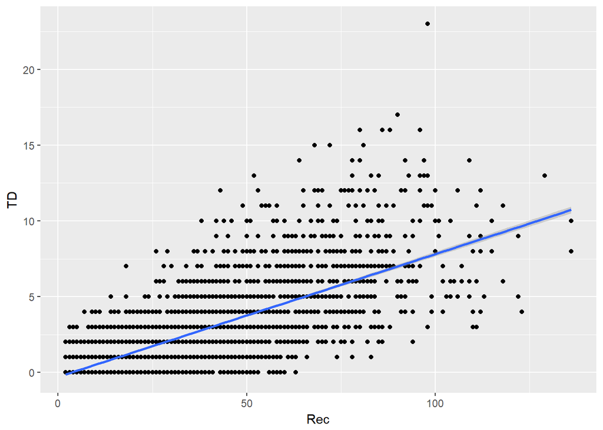

```r
all_table %>%
ggplot(aes(x= Rec, y= TD))+geom_point()+geom_smooth(method = lm)
```

This shows that as a player has more receptions they will score more touchdowns. Which makes sense. However we can then inspect it upon a year by year basis and see how the slopes change each year.

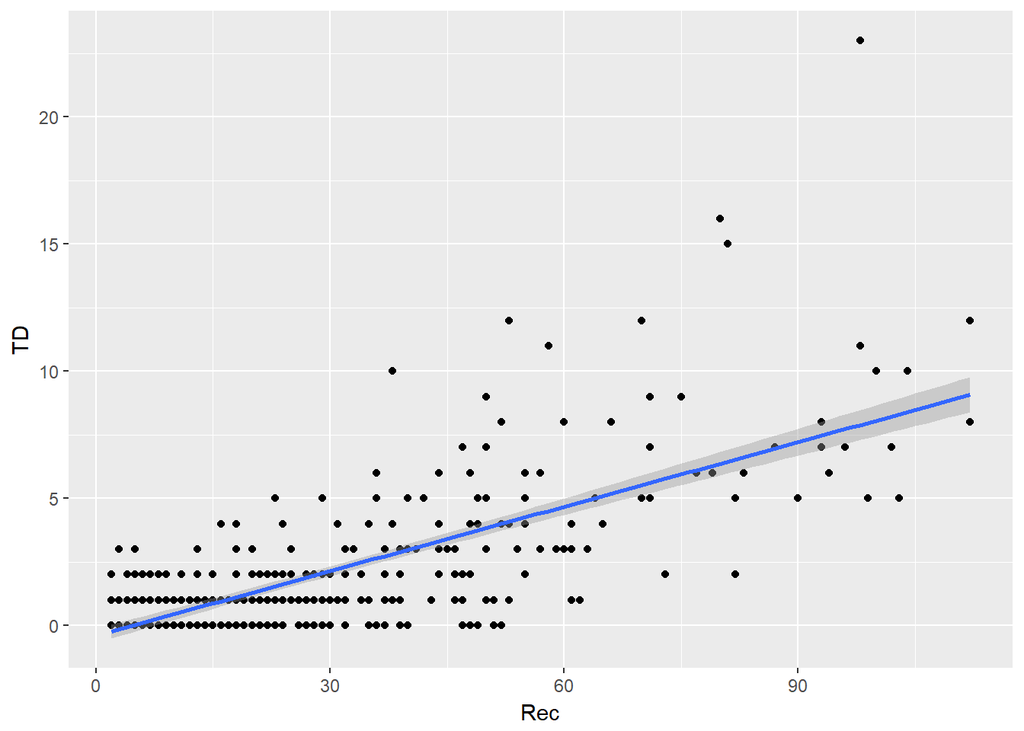

```r
table2007%>%
ggplot(aes(x=Rec,y=TD))+geom_point() +geom_smooth(method= lm)
```

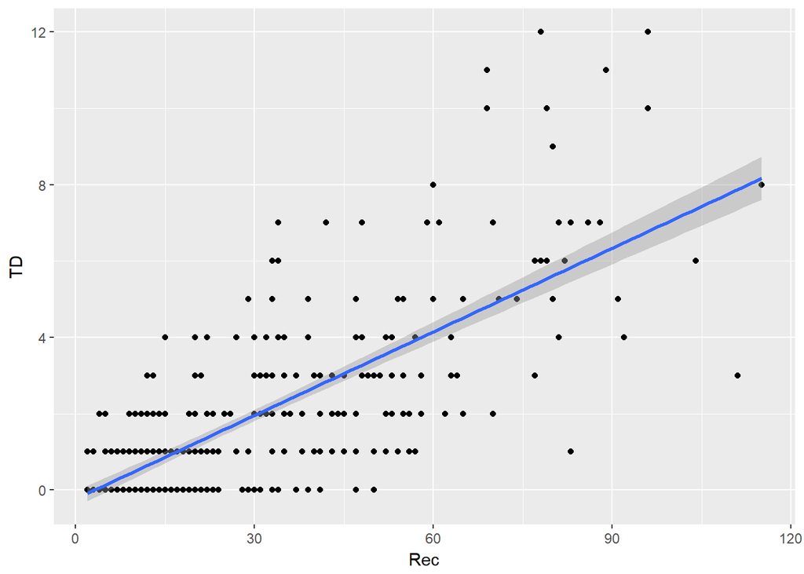

```r
table2008%>%
ggplot(aes(x=Rec,y=TD))+geom_point() +geom_smooth(method= lm)
```

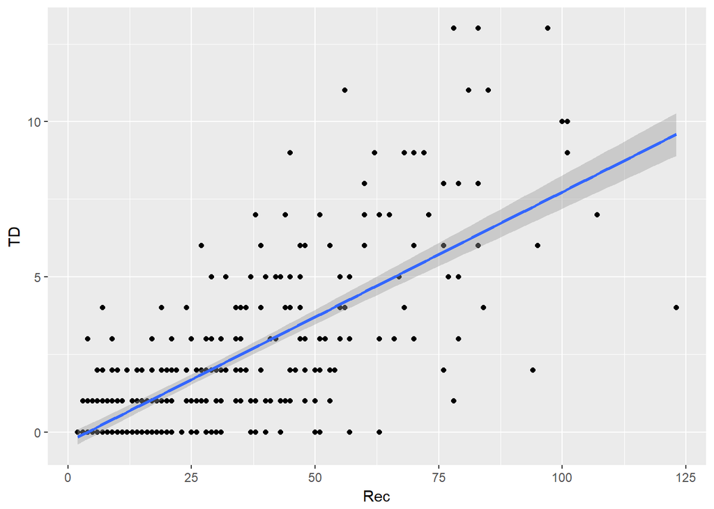

```r
table2009%>%
ggplot(aes(x=Rec,y=TD))+geom_point() +geom_smooth(method= lm)
```

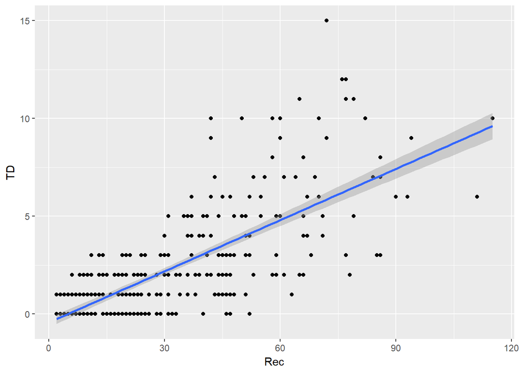

```r
table2010%>%
ggplot(aes(x=Rec,y=TD))+geom_point() +geom_smooth(method= lm)
```

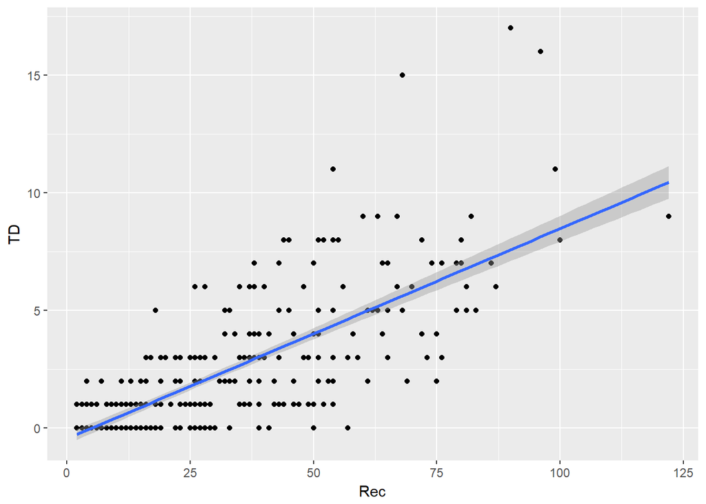

```r
table2011%>%
ggplot(aes(x=Rec,y=TD))+geom_point() +geom_smooth(method= lm)
```

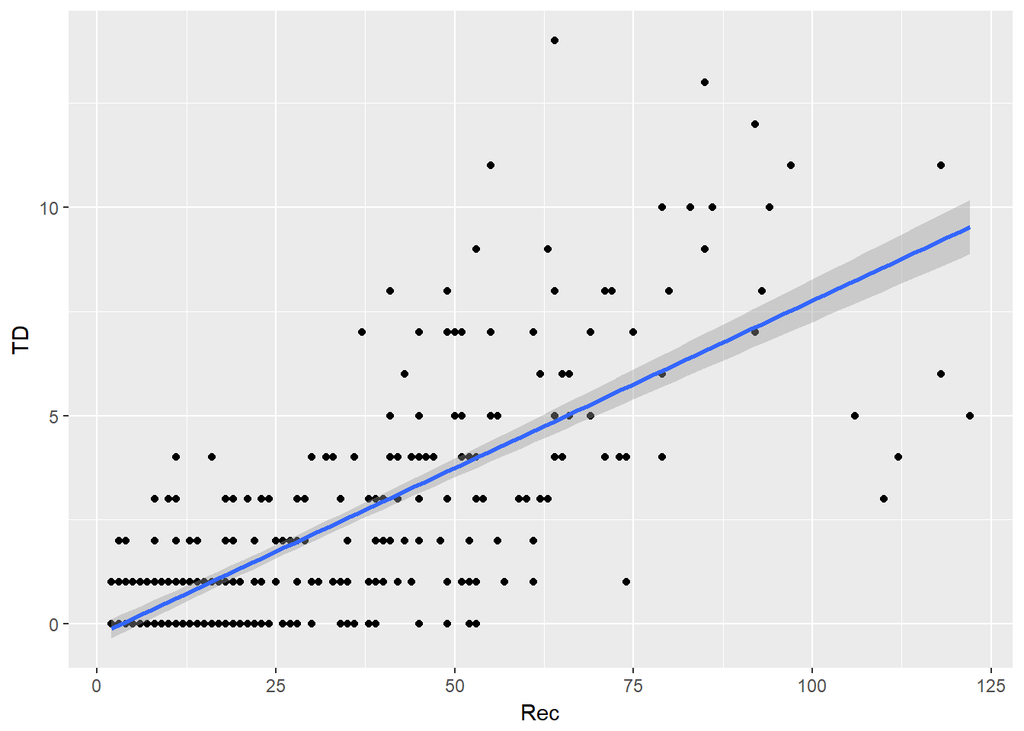

```r
table2012%>%
ggplot(aes(x=Rec,y=TD))+geom_point() +geom_smooth(method= lm)
```

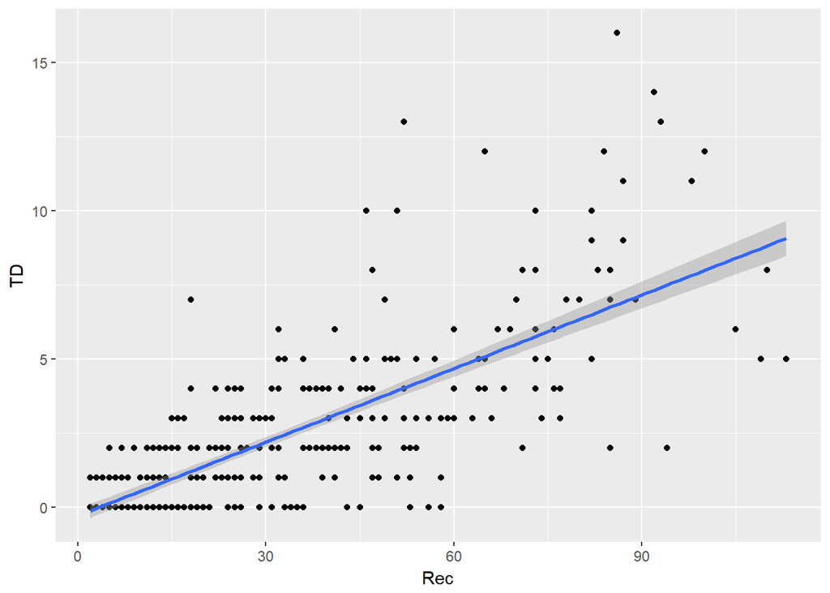

```r
table2013%>%
ggplot(aes(x=Rec,y=TD))+geom_point() +geom_smooth(method= lm)
```

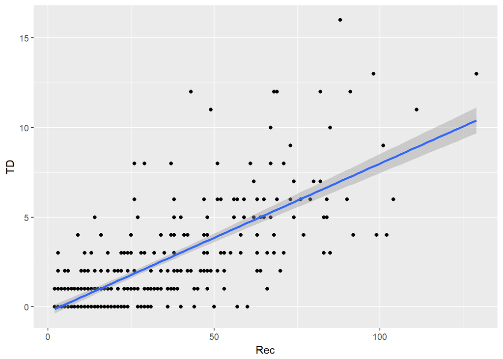

```r
table2014%>%
ggplot(aes(x=Rec,y=TD))+geom_point() +geom_smooth(method= lm)
```

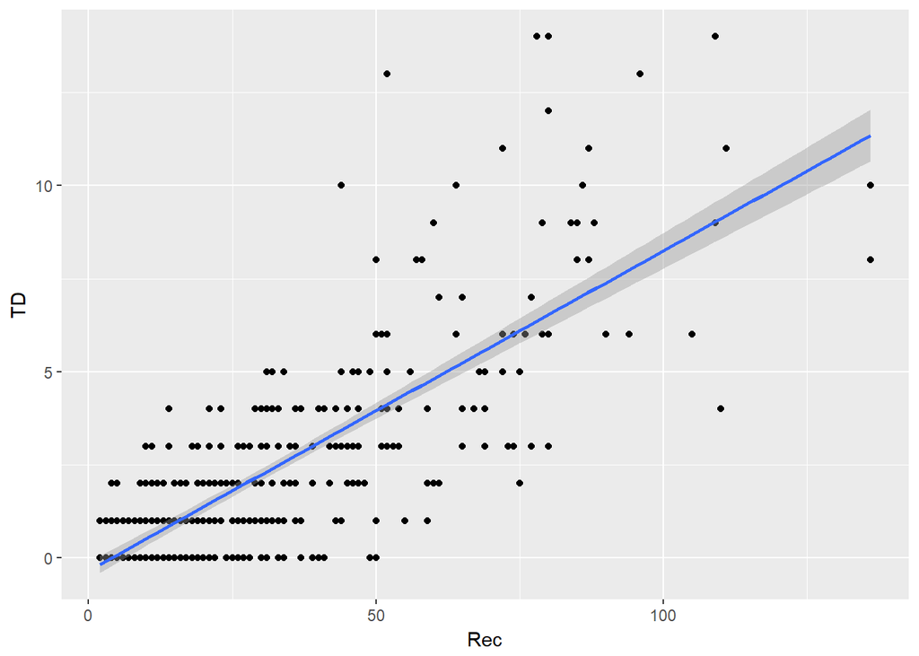

```r
table2015%>%
ggplot(aes(x=Rec,y=TD))+geom_point() +geom_smooth(method= lm)
```

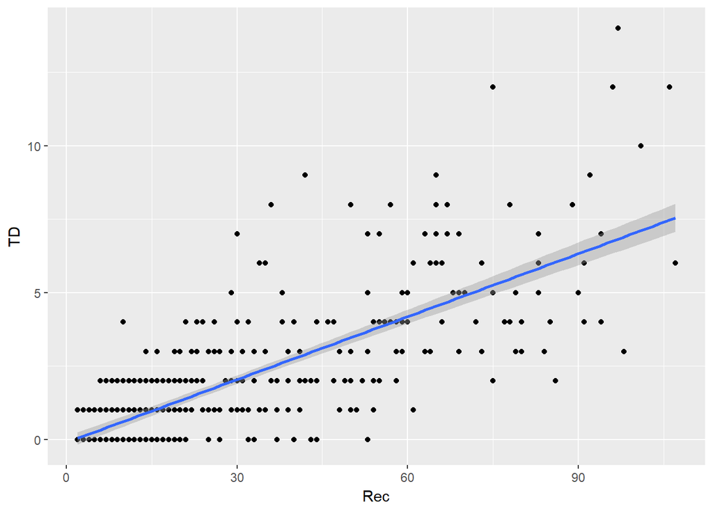

```r
table2016%>%
ggplot(aes(x=Rec,y=TD))+geom_point() +geom_smooth(method= lm)
```

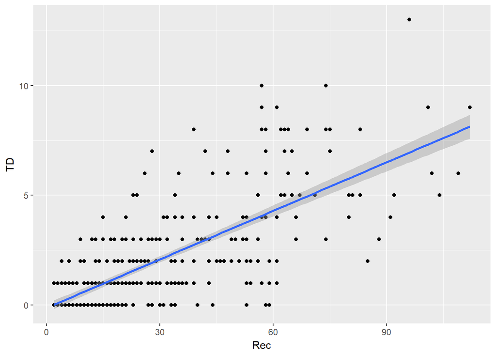

```r
table2017%>%
ggplot(aes(x=Rec,y=TD))+geom_point() +geom_smooth(method= lm)
```

Another way of looking at the reception to touchdown ratio is to consider the position one is playing. The main three positions who recieve passes are tight-end, wide-reciever and runningback.

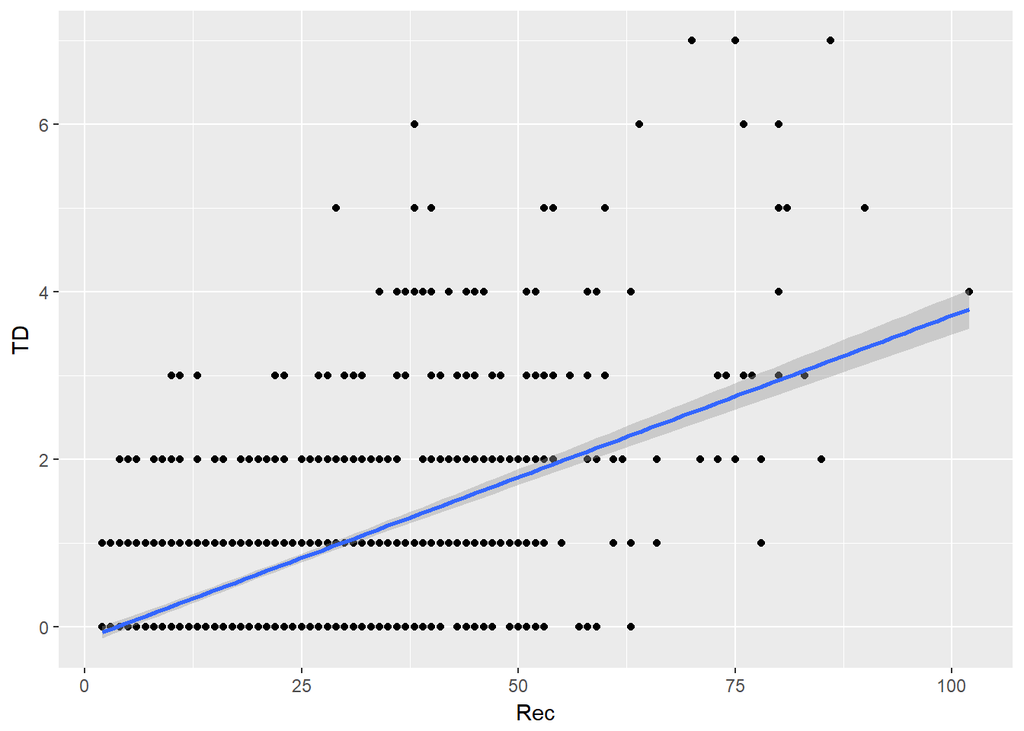

```r
  running_back_table%>%
ggplot(aes(x=Rec,y=TD))+geom_point() +geom_smooth(method= lm)
```

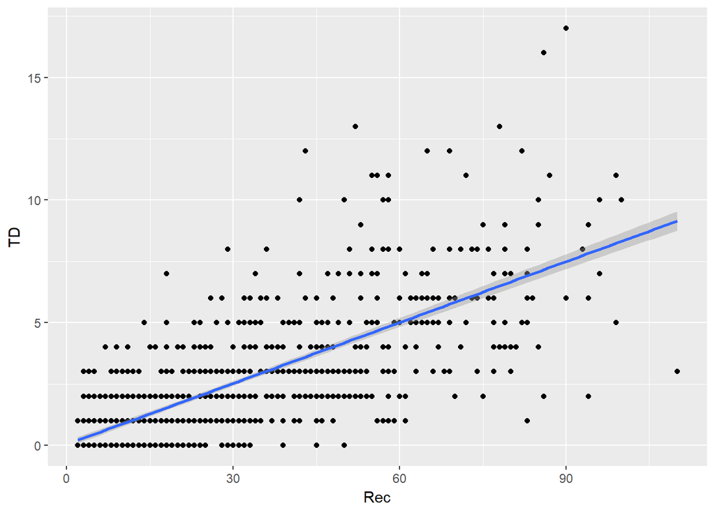

```r
  tight_end_table%>%
ggplot(aes(x=Rec,y=TD))+geom_point() +geom_smooth(method= lm)
```

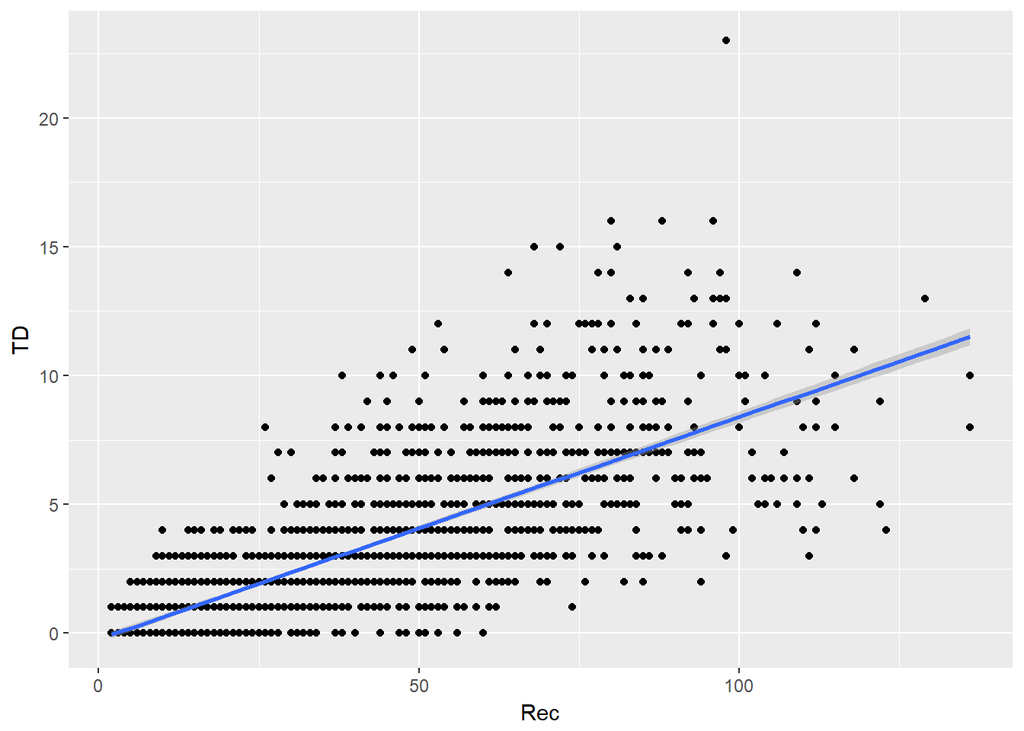

```r
  wide_receiver_table%>%
  ggplot(aes(x=Rec,y=TD))+geom_point() +geom_smooth(method= lm)
```

Other important things to look at when trying to understand the data are things such as mean for both the total number of receptions.

```r
  mean(all_table$Rec)
```

```
## [1] 26.58452
```

```r
  mean(all_table$TD)
```

```
## [1] 1.861281
```

3. Machine Learning

Machine learning is using data we already have in order to look ahead and try to predict the future. We are going to use machine learning today to see if we can predict how many touchdowns a player has scored based off of the number of receptions they have.

```r
library(broom)
interaction <- tidy(lm(formula = TD ~ Rec, data = all_table ))

interaction
```

```
##          term    estimate   std.error statistic    p.value
## 1 (Intercept) -0.29251109 0.037011939 -7.903155 3.4079e-15
## 2         Rec  0.08101677 0.001023821 79.131793 0.0000e+00
```

After taking an original slope using all of the potential data we can also see how each position can have their own slope meaning that the rate is slightly different for each individual.

```r
interaction_Wr <- tidy(lm(formula = TD~Rec,data = wide_receiver_table))

interaction_te <- tidy(lm(formula = TD~Rec, data = tight_end_table))

interaction_rb <- tidy(lm(formula = TD~Rec,data = running_back_table))

interaction_Wr
```

```
##          term    estimate   std.error statistic      p.value
## 1 (Intercept) -0.23868121 0.069960572 -3.411653 0.0006593433
## 2         Rec  0.08629677 0.001577527 54.703827 0.0000000000
```

```r
interaction_te
```

```
##          term   estimate   std.error  statistic       p.value
## 1 (Intercept) 0.04069617 0.074891098  0.5434047  5.869689e-01
## 2         Rec 0.08279840 0.002241175 36.9441880 7.202820e-191
```

```r
interaction_rb
```

```
##          term    estimate   std.error statistic       p.value
## 1 (Intercept) -0.13953915 0.038273782 -3.645815  2.780726e-04
## 2         Rec  0.03859285 0.001417538 27.225276 3.135881e-127
```

Another way of looking at the data is to look at it on a yearly basis. We can take a look at each year and see how the data in that year looks.

```r
interaction_2007 <- tidy(lm(formula = TD~Rec,data = table2007))

interaction_2008 <- tidy(lm(formula = TD~Rec, data = table2008))

interaction_2009 <- tidy(lm(formula = TD~Rec,data = table2009))
interaction_2010 <- tidy(lm(formula = TD~Rec,data = table2010))

interaction_2011 <- tidy(lm(formula = TD~Rec, data = table2011))

interaction_2012 <- tidy(lm(formula = TD~Rec,data = table2012))

interaction_2013 <- tidy(lm(formula = TD~Rec,data = table2013))

interaction_2014 <- tidy(lm(formula = TD~Rec, data = table2014))

interaction_2015 <- tidy(lm(formula = TD~Rec,data = table2015))
interaction_2016 <- tidy(lm(formula = TD~Rec,data = table2016))

interaction_2017 <- tidy(lm(formula = TD~Rec, data = table2017))

interaction_2007
```

```
##          term    estimate  std.error statistic      p.value
## 1 (Intercept) -0.40206542 0.14359943  -2.79991 5.369202e-03
## 2         Rec  0.08460339 0.00396794  21.32174 3.603998e-67
```

```r
interaction_2008
```

```
##          term    estimate   std.error statistic      p.value
## 1 (Intercept) -0.23486947 0.107679075 -2.181199 2.976388e-02
## 2         Rec  0.07302307 0.003093985 23.601624 3.322885e-77
```

```r
interaction_2009
```

```
##          term    estimate   std.error statistic      p.value
## 1 (Intercept) -0.31910558 0.125844453 -2.535714 1.161547e-02
## 2         Rec  0.08053569 0.003510976 22.938265 4.408561e-74
```

```r
interaction_2010
```

```
##          term    estimate   std.error statistic      p.value
## 1 (Intercept) -0.43303130 0.132276792 -3.273676 1.156843e-03
## 2         Rec  0.08730476 0.003743992 23.318631 8.163930e-76
```

```r
interaction_2011
```

```
##          term    estimate   std.error statistic      p.value
## 1 (Intercept) -0.45042770 0.125113047 -3.600166 3.583870e-04
## 2         Rec  0.08929976 0.003574992 24.979009 2.258374e-83
```

```r
interaction_2012
```

```
##          term    estimate   std.error statistic      p.value
## 1 (Intercept) -0.27333461 0.122617545 -2.229164 2.635914e-02
## 2         Rec  0.08034463 0.003349073 23.990107 2.211411e-79
```

```r
interaction_2013
```

```
##          term    estimate   std.error statistic      p.value
## 1 (Intercept) -0.27315269 0.124727774 -2.189991 2.909179e-02
## 2         Rec  0.08270997 0.003373293 24.519058 3.471518e-82
```

```r
interaction_2014
```

```
##          term    estimate   std.error statistic      p.value
## 1 (Intercept) -0.29008104 0.130251177  -2.22709 2.648897e-02
## 2         Rec  0.08286142 0.003498093  23.68760 1.565817e-78
```

```r
interaction_2015
```

```
##          term    estimate   std.error statistic      p.value
## 1 (Intercept) -0.34483874 0.119096452 -2.895458 3.988064e-03
## 2         Rec  0.08593925 0.003185105 26.981605 5.244205e-93
```

```r
interaction_2016
```

```
##          term    estimate   std.error  statistic      p.value
## 1 (Intercept) -0.10069524 0.109589967 -0.9188363 3.587201e-01
## 2         Rec  0.07144882 0.002926575 24.4138002 5.331828e-82
```

```r
interaction_2017
```

```
##          term   estimate   std.error statistic      p.value
## 1 (Intercept) -0.1284438 0.106434498 -1.206787 2.281983e-01
## 2         Rec  0.0737156 0.003079339 23.938776 2.582718e-80
```

Finally we can try and compound some of these factors. This formula below tests year as well as Position in their efforts

```r
interaction <- tidy(lm(formula = TD ~ Rec*Pos*year, data=all_table))
interaction
```

```
##              term      estimate    std.error     statistic     p.value
## 1     (Intercept) -4.204452e+00 1.000410e+03 -0.0042027301 0.996646907
## 2             Rec  1.868258e+00 1.038243e+00  1.7994422475 0.072017396
## 3           PosDB  9.279829e-04 2.269250e+00  0.0004089381 0.999673733
## 4           PosDE  4.175935e-03 1.313135e+01  0.0003180125 0.999746277
## 5           PosDT  4.639907e-04 2.003392e+00  0.0002316026 0.999815218
## 6           PosFB -1.154430e+01 1.004606e+03 -0.0114913733 0.990831935
## 7            PosG  6.959868e-04 2.082168e+00  0.0003342607 0.999733314
## 8          PosOLB  2.002320e+00 4.513403e+00  0.4436386274 0.657325737
## 9           PosQB -2.311859e+02 1.081895e+03 -0.2136860210 0.830801836
## 10          PosRB  6.786438e+00 1.001381e+03  0.0067770808 0.994593021
## 11           PosT  1.467936e+00 2.428886e+03  0.0006043661 0.999517813
## 12          PosTE -6.309989e+00 1.001428e+03 -0.0063009907 0.994972856
## 13          PosWR -4.284817e+01 1.001025e+03 -0.0428042844 0.965859495
## 14           year  2.087958e-03 4.961013e-01  0.0042087334 0.996642118
## 15      Rec:PosDE  9.990720e-01 4.437258e+00  0.2251552846 0.821868954
## 16      Rec:PosFB -2.123537e+00 7.905142e+00 -0.2686273043 0.788229121
## 17      Rec:PosRB -4.899292e+00 1.925300e+00 -2.5446898579 0.010971433
## 18      Rec:PosTE -2.279236e+00 1.737517e+00 -1.3117775516 0.189663795
## 19      Rec:PosWR  8.534400e-02 6.305342e-01  0.1353519045 0.892339854
## 20       Rec:year -9.279811e-04 4.097104e-04 -2.2649684476 0.023563155
## 21     PosFB:year  5.751407e-03 4.981924e-01  0.0115445500 0.990789511
## 22     PosQB:year  1.151526e-01 5.371042e-01  0.2143952898 0.830248772
## 23     PosRB:year -3.436531e-03 4.965849e-01 -0.0069203284 0.994478735
## 24      PosT:year -2.319961e-04 1.207378e+00 -0.0001921487 0.999846696
## 25     PosTE:year  3.157495e-03 4.966085e-01  0.0063581164 0.994927280
## 26     PosWR:year  2.117572e-02 4.964079e-01  0.0426579037 0.965976177
## 27 Rec:PosFB:year  1.080778e-03 3.916902e-03  0.2759266612 0.782617383
## 28 Rec:PosRB:year  2.453301e-03 9.038930e-04  2.7141492181 0.006670585
## 29 Rec:PosTE:year  1.173388e-03 8.045414e-04  1.4584562909 0.144786352
```

Another way of attempting to create something to predict how many tocudowns a person would score would be to use a tree. When using a tree one can follow how many receptions a person has and if it is more than the number provided travel right and if it is less travel left and see how many Touchdowns a pass catcher should score.

```r
library(tree)
train <- sample(1:nrow(all_table),nrow(all_table)/2)
tree.rec <- tree(TD~.,all_table%>%select(Rec,Pos,TD))
summary(tree.rec)
```

```
##
## Regression tree:
## tree(formula = TD ~ ., data = all_table %>% select(Rec, Pos,
##     TD))
## Variables actually used in tree construction:
## [1] "Rec"
## Number of terminal nodes:  5
## Residual mean deviance:  2.83 = 12490 / 4414
## Distribution of residuals:
##    Min. 1st Qu.  Median    Mean 3rd Qu.    Max.
## -6.7920 -0.5086 -0.5086  0.0000  0.4914 15.2100
```

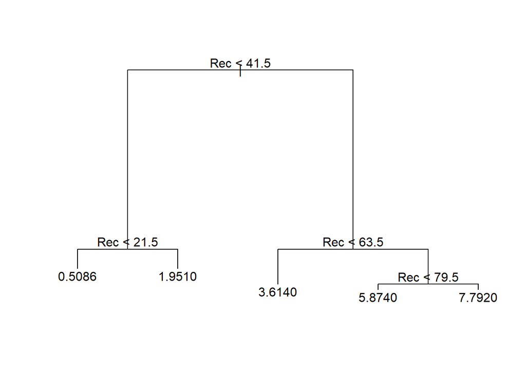

```r
plot(tree.rec)
text(tree.rec,pretty=0)
```

Links I used: These are some links that can help your understanding if you are confused about any of the topics I talked about.

Trees: http://rstudio-pubs-static.s3.amazonaws.com/156481_80ee6ee3a0414fd38f5d3ad33d14c771.html

Linear Regression: http://r-statistics.co/Linear-Regression.html

Plotting: https://www.statmethods.net/advgraphs/ggplot2.html